# Lab 2B

Feature selection

2021

```r
knitr::opts_chunk$set(eval=params$answers, message=FALSE)
library(ISLR)
library(tidyverse)
library(glmnet)
library(caret)
library(gridExtra)
```

For this lab you need the packages `ISLR`, `ggplot2`, `glmnet`, `caret`, and `gridExtra`.

The data set for this lab is `College`, check the help page for its content.

The lab is structured as follows:

1. Explore, normalize and standardize the data
2. Split data in train/test set
3. Train filter, wrapper and embedded methods, and compare test MSE
4. Introduce two-way interactions effects, and train the lasso

# 1 Data preparation

1. Display a summary of the data set. Check for impossible values (e.g. percentage outside the range 0-100), and delete these cases from the data (overwrite the original data).

```r
summary(College)
```

```
##  Private        Apps           Accept          Enroll       Top10perc
##  No :212   Min.   :   81   Min.   :   72   Min.   :  35   Min.   : 1.00
##  Yes:565   1st Qu.:  776   1st Qu.:  604   1st Qu.: 242   1st Qu.:15.00
##            Median : 1558   Median : 1110   Median : 434   Median :23.00
##            Mean   : 3002   Mean   : 2019   Mean   : 780   Mean   :27.56
##            3rd Qu.: 3624   3rd Qu.: 2424   3rd Qu.: 902   3rd Qu.:35.00
##            Max.   :48094   Max.   :26330   Max.   :6392   Max.   :96.00
##    Top25perc      F.Undergrad     P.Undergrad         Outstate
##  Min.   :  9.0   Min.   :  139   Min.   :    1.0   Min.   : 2340
##  1st Qu.: 41.0   1st Qu.:  992   1st Qu.:   95.0   1st Qu.: 7320
##  Median : 54.0   Median : 1707   Median :  353.0   Median : 9990
##  Mean   : 55.8   Mean   : 3700   Mean   :  855.3   Mean   :10441
##  3rd Qu.: 69.0   3rd Qu.: 4005   3rd Qu.:  967.0   3rd Qu.:12925
##  Max.   :100.0   Max.   :31643   Max.   :21836.0   Max.   :21700
##    Room.Board       Books           Personal         PhD
##  Min.   :1780   Min.   :  96.0   Min.   : 250   Min.   :  8.00
##  1st Qu.:3597   1st Qu.: 470.0   1st Qu.: 850   1st Qu.: 62.00
##  Median :4200   Median : 500.0   Median :1200   Median : 75.00
##  Mean   :4358   Mean   : 549.4   Mean   :1341   Mean   : 72.66
##  3rd Qu.:5050   3rd Qu.: 600.0   3rd Qu.:1700   3rd Qu.: 85.00
##  Max.   :8124   Max.   :2340.0   Max.   :6800   Max.   :103.00
##     Terminal       S.F.Ratio      perc.alumni        Expend
##  Min.   : 24.0   Min.   : 2.50   Min.   : 0.00   Min.   : 3186
##  1st Qu.: 71.0   1st Qu.:11.50   1st Qu.:13.00   1st Qu.: 6751
##  Median : 82.0   Median :13.60   Median :21.00   Median : 8377
##  Mean   : 79.7   Mean   :14.09   Mean   :22.74   Mean   : 9660
##  3rd Qu.: 92.0   3rd Qu.:16.50   3rd Qu.:31.00   3rd Qu.:10830
##  Max.   :100.0   Max.   :39.80   Max.   :64.00   Max.   :56233
##    Grad.Rate
##  Min.   : 10.00
##  1st Qu.: 53.00
##  Median : 65.00
##  Mean   : 65.46
##  3rd Qu.: 78.00
##  Max.   :118.00
```

```r
College <- College %>%
  filter(Grad.Rate <= 100,
         PhD <= 100)
```

2. Since we are going fit linear models, we want the variables in the data to have approximately normal distributions. To visually check for skew and outliers, standardize all variables in the data set (first convert the dichotomous factor `Private` into a numeric variable), and display the boxplots of the standardized variables in a single plot array.

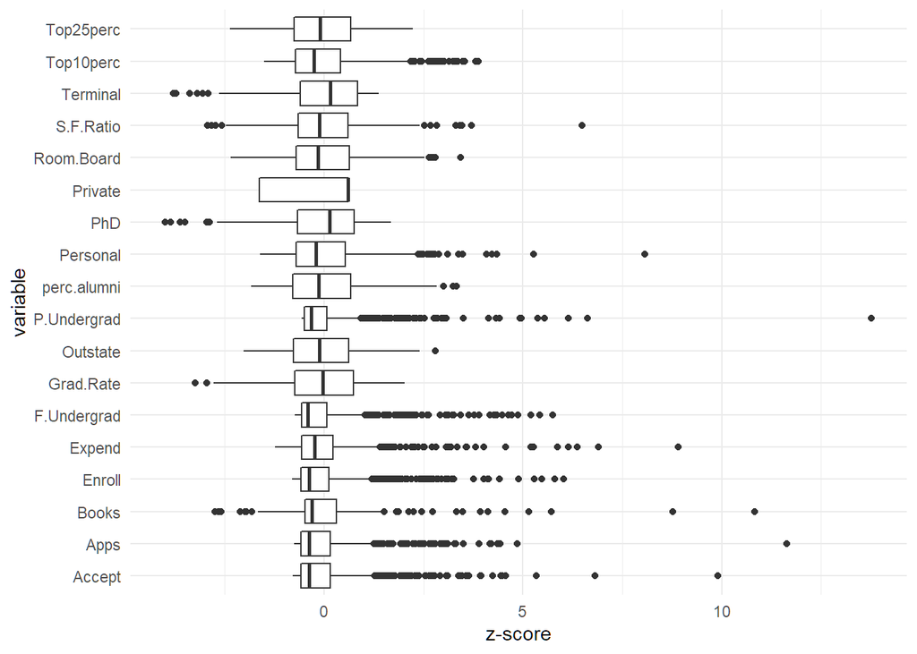

```r
College %>%
  mutate(Private = as.numeric(Private),
         across(everything(), scale)) %>%
  pivot_longer(everything(), values_to = "z-score", names_to = "variable") %>%
  ggplot(aes(`z-score`, variable)) +
  geom_boxplot() +
  theme_minimal()
```

3. Apply a normalizing log transformation to the variables with heavy skew (for variables with left skew, first reverse the scores). Make sure that before you transform the variables their minimum score is 1, in order to avoid taking the log of 0, which is infinite. Display the boxplots of the transformed variables to check if the transformation had the desired effect, and then save the resulting data (overwrite the previous version of `College`).

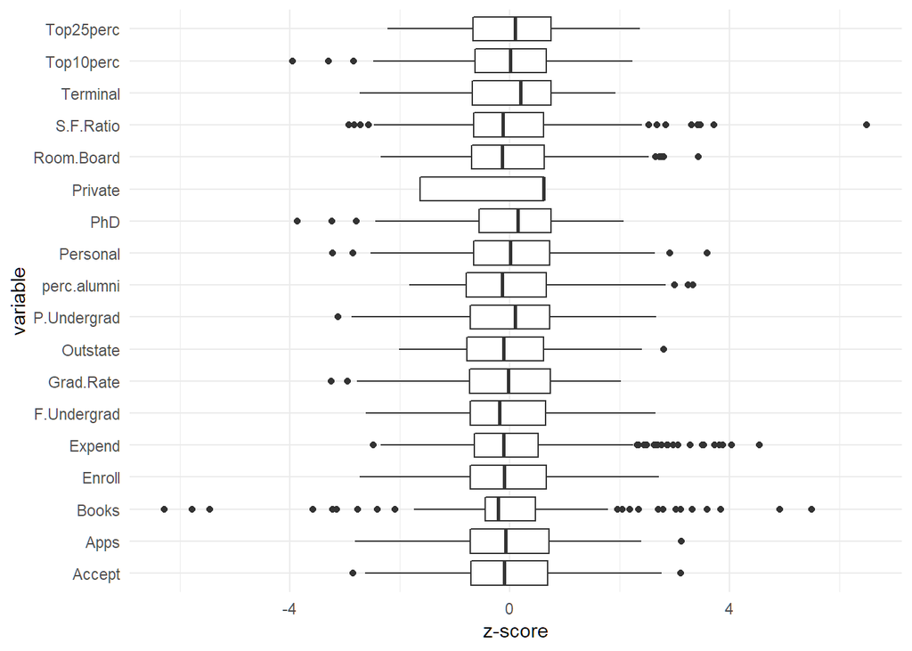

```r
College <- College %>%
  mutate(Private = as.numeric(Private),
         across(c(PhD, Top25perc, Terminal), ~{101 - .}),
         across(c(2, 3, 4, 5, 7, 8, 11, 12, 13, 14, 17), ~ log(. + 1)),
         across(everything(), scale))

College  %>%
  pivot_longer(everything(), values_to = "z-score", names_to = "variable") %>%
  ggplot(aes(`z-score`, variable)) +
  geom_boxplot() +
  theme_minimal()
```

4. Display 16 scatterplots with `Grad.Rate` on the y-axis and the respective 16 numeric predictors on x-axis (so exclude `Private`). Check the scatterplots for non-linearity.

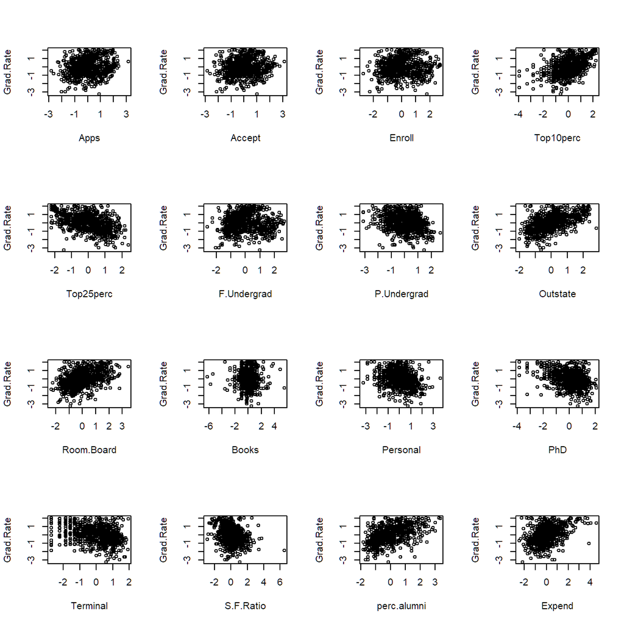

```r
par(mfrow = c(4, 4))
for(i in 2:17)plot(College[, c(i, 18)], cex = .7)
```

# 2 Train/test set

1. Create the vector `train` with the row numbers for the train set containing of 75% of the cases. Set the seed to 1 for reproducibility of the results.

```r
set.seed(1)
train <- createDataPartition(y = College$Grad.Rate, p = .75, list = FALSE)
```

## 2.1 Filter method

Filter methods select a set of features before training the model. For these we will select features from the training set based on a minimum correlation with `Grad.Rate`. As selection criterion we use an absolute correlation larger than 0.3.

1. Display the last column of the correlation matrix of the training set (the 18th column pertaining to outcome variable `Grad.Rate`). Which features satisfy the criterion?

```r
cor(College[train, ])[-18, 18] %>%  round(3)
```

```
##     Private        Apps      Accept      Enroll   Top10perc   Top25perc
##       0.332       0.193       0.137       0.068       0.484      -0.472
## F.Undergrad P.Undergrad    Outstate  Room.Board       Books    Personal
##       0.012      -0.265       0.573       0.400      -0.014      -0.303
##         PhD    Terminal   S.F.Ratio perc.alumni      Expend
##      -0.337      -0.275      -0.291       0.485       0.426
```

2. Make a character vector `vars` containing the names of the features that satisfy our selection criterion.

```r
vars <- which(abs(cor(College[train, ])[-18, 18]) > .3)
```

3. Fit the linear model to the training data with the selected features as predictors of `Grad.Rate`, and save the object as `train_filter`.

```r
train_filter <- lm(Grad.Rate ~ ., data = College[train, c(vars, 18)])
```

4. Display the summary of `train_filter`. Although all predictors have an absolute correlation of at least .3 with `Grad.rate`, some of them are not significant as predictor? Why is that?

```r
summary(train_filter)
```

```
##
## Call:
## lm(formula = Grad.Rate ~ ., data = College[train, c(vars, 18)])
##
## Residuals:
##     Min      1Q  Median      3Q     Max
## -3.3806 -0.4555 -0.0506  0.4766  2.5964
##
## Coefficients:
##              Estimate Std. Error t value Pr(>|t|)
## (Intercept)  0.009369   0.031268   0.300 0.764566
## Private      0.037657   0.043846   0.859 0.390783
## Top10perc    0.151581   0.076168   1.990 0.047058 *
## Top25perc   -0.151981   0.074504  -2.040 0.041819 *
## Outstate     0.343484   0.064161   5.353 1.25e-07 ***
## Room.Board   0.120001   0.044054   2.724 0.006648 **
## Personal    -0.086358   0.034953  -2.471 0.013776 *
## PhD         -0.043178   0.046708  -0.924 0.355653
## perc.alumni  0.167787   0.040522   4.141 3.99e-05 ***
## Expend      -0.231074   0.059068  -3.912 0.000103 ***
## ---
## Signif. codes:  0 '***' 0.001 '**' 0.01 '*' 0.05 '.' 0.1 ' ' 1
##
## Residual standard error: 0.7523 on 572 degrees of freedom
## Multiple R-squared:  0.4336, Adjusted R-squared:  0.4247
## F-statistic: 48.66 on 9 and 572 DF,  p-value: < 2.2e-16
```

5. Obtain and save the predictions for the test set

```r
filter_pred <- predict(train_filter, newdata = College[-train, ])
```

6. Compute and display the test MSE. Save this value as `filter_mse`.

```r
filter_mse  <- mean((College[-train, "Grad.Rate"] - filter_pred)^2)
```

## 2.2 Wrapper method

Wrapper methods select features while training the model. Here we use the backward step-wise selection procedure. Check the help page of the function `step()` for assistance on how to conduct a backward step-wise selection.

1. Fit the linear model with all features as predictors, and apply the backward step-wise `step()` procedure. Save the result under the name `train_step`.

```r
train_step <- step(lm(Grad.Rate ~ ., College[train, ]))
```

```
## Start:  AIC=-360.59
## Grad.Rate ~ Private + Apps + Accept + Enroll + Top10perc + Top25perc +
##     F.Undergrad + P.Undergrad + Outstate + Room.Board + Books +
##     Personal + PhD + Terminal + S.F.Ratio + perc.alumni + Expend
##
##               Df Sum of Sq    RSS     AIC
## - P.Undergrad  1    0.1576 294.59 -362.28
## - Enroll       1    0.3237 294.75 -361.95
## - S.F.Ratio    1    0.4713 294.90 -361.66
## - F.Undergrad  1    0.5348 294.97 -361.53
## - Top25perc    1    0.7682 295.20 -361.07
## <none>                     294.43 -360.59
## - Top10perc    1    1.3248 295.76 -359.98
## - PhD          1    2.0101 296.44 -358.63
## - Room.Board   1    2.7915 297.22 -357.10
## - Books        1    3.1568 297.59 -356.38
## - Terminal     1    3.5352 297.97 -355.64
## - Personal     1    4.5637 298.99 -353.64
## - Accept       1    7.1264 301.56 -348.67
## - Private      1    7.1673 301.60 -348.59
## - Expend       1    7.9052 302.34 -347.17
## - Apps         1   10.0217 304.45 -343.11
## - perc.alumni  1   11.9951 306.43 -339.35
## - Outstate     1   12.5187 306.95 -338.36
##
## Step:  AIC=-362.28
## Grad.Rate ~ Private + Apps + Accept + Enroll + Top10perc + Top25perc +
##     F.Undergrad + Outstate + Room.Board + Books + Personal +
##     PhD + Terminal + S.F.Ratio + perc.alumni + Expend
##
##               Df Sum of Sq    RSS     AIC
## - Enroll       1    0.3848 294.97 -363.52
## - F.Undergrad  1    0.3958 294.98 -363.50
## - S.F.Ratio    1    0.4250 295.01 -363.44
## - Top25perc    1    0.8189 295.41 -362.66
## <none>                     294.59 -362.28
## - Top10perc    1    1.3434 295.93 -361.63
## - PhD          1    2.0751 296.66 -360.19
## - Room.Board   1    2.6471 297.24 -359.07
## - Books        1    3.0751 297.66 -358.24
```

[output cut: 59 more lines]

```
##               Df Sum of Sq    RSS     AIC
## <none>                     296.21 -365.08
## - PhD          1    1.8784 298.09 -363.40
## - F.Undergrad  1    2.1293 298.34 -362.91
## - Room.Board   1    2.4163 298.63 -362.35
## - Books        1    2.7978 299.01 -361.61
## - Terminal     1    3.3950 299.61 -360.45
## - Personal     1    4.9650 301.18 -357.41
## - Private      1    7.1433 303.36 -353.21
## - Accept       1    8.2240 304.44 -351.14
## - Expend       1    8.5642 304.78 -350.49
## - Top10perc    1   11.1439 307.36 -345.59
## - Apps         1   11.8027 308.01 -344.34
## - Outstate     1   12.9218 309.13 -342.23
## - perc.alumni  1   14.3179 310.53 -339.61
```

2. Display the summary of the step model. Compare the explained variance of this model and the filter model. Which model performs best on the training data?

```r
summary(train_step)
```

```
##
## Call:
## lm(formula = Grad.Rate ~ Private + Apps + Accept + Top10perc +
##     F.Undergrad + Outstate + Room.Board + Books + Personal +
##     PhD + Terminal + perc.alumni + Expend, data = College[train,
##     ])
##
## Residuals:
##      Min       1Q   Median       3Q      Max
## -3.10708 -0.42740 -0.01305  0.40560  2.52999
##
## Coefficients:
##             Estimate Std. Error t value Pr(>|t|)
## (Intercept)  0.01934    0.02999   0.645 0.519287
## Private      0.20139    0.05442   3.701 0.000236 ***
## Apps         0.75857    0.15945   4.757 2.49e-06 ***
## Accept      -0.66572    0.16764  -3.971 8.07e-05 ***
## Top10perc    0.20201    0.04370   4.623 4.69e-06 ***
## F.Undergrad  0.19810    0.09804   2.021 0.043787 *
## Outstate     0.31736    0.06376   4.978 8.54e-07 ***
## Room.Board   0.09373    0.04355   2.153 0.031775 *
## Books       -0.06978    0.03013  -2.316 0.020902 *
## Personal    -0.10686    0.03463  -3.086 0.002131 **
## PhD         -0.11441    0.06028  -1.898 0.058221 .
## Terminal     0.14271    0.05593   2.551 0.010987 *
## perc.alumni  0.20572    0.03926   5.240 2.27e-07 ***
## Expend      -0.23492    0.05797  -4.052 5.77e-05 ***
## ---
## Signif. codes:  0 '***' 0.001 '**' 0.01 '*' 0.05 '.' 0.1 ' ' 1
##
## Residual standard error: 0.7221 on 568 degrees of freedom
## Multiple R-squared:  0.4817, Adjusted R-squared:  0.4699
## F-statistic: 40.61 on 13 and 568 DF,  p-value: < 2.2e-16
```

3. Obtain and save the predictions of the step model for the test set.

```r
pred_step  <- predict(train_step, newdata = College[-train, ])
```

4. Compute the test MSE for the step model, and save it as `step_mse`.

```r
(step_mse <- mean((College[-train, "Grad.Rate"] - pred_step)^2))
```

```
## [1] 0.6035464
```

## 2.3 Embedded method

In the embedded method, the feature selection process is embedded in the model training phase. We use the function `glmnet()` to fit the lasso and ridge models to the training data. This function computes the deviance for a sequence of values of the hyperparameter `lambda`, which determines the budget for the coefficients. The function `cv.glmnet()` is then applied to object created with `glmnet()` to determine the optimal value for `lambda` with cross-validation.

1. Create the objects `train_lasso` and `train_ridge` with `glmnet()`. Set the argument `alpha = 1` for the lasso, and `alpha = 0` for the ridge. Do not forget that the argument `x` has to be of class `matrix`!

```r
train_ridge <- glmnet(x = as.matrix(College[train, -18]),
                      y = College[train, 18],
                      alpha = 0)

train_lasso <- glmnet(x = as.matrix(College[train, -18]),
                      y = College[train, 18],
                      alpha = 1)
```

2. Plot both `glmnet` objects. Interpret the plots.

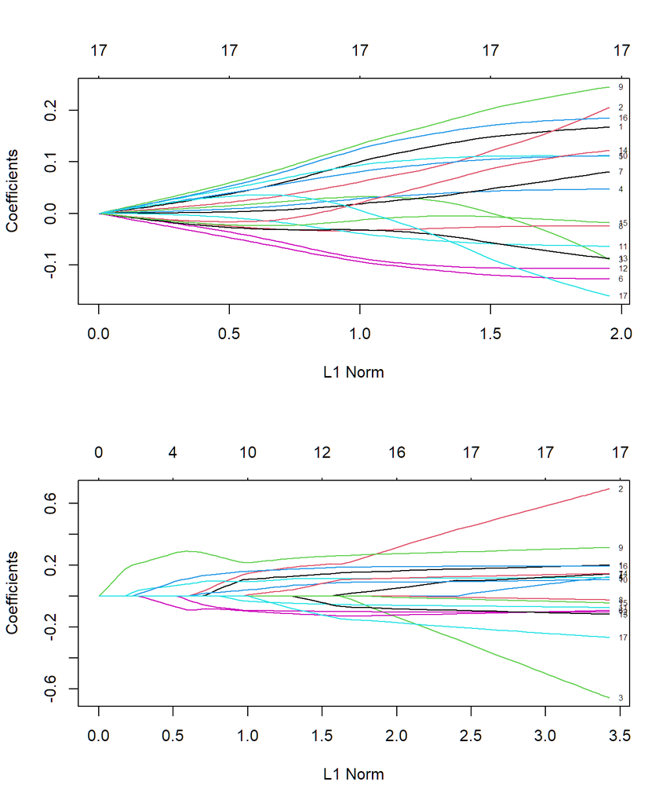

```r
par(mfrow=c(2,1))
plot(train_ridge, label = T)
plot(train_lasso, label = T)
```

3. Cross-validate with `cv.glmnet()` to find the optimal `lambda` values for `alpha=0` an `alpha=1`. Include the argument `type.measure = "mse"`. Save the objects as `cv_ridge` and `cv_lasso`.

```r
cv_ridge <- cv.glmnet(x = as.matrix(College[train, -18]),
                      y = College[train, 18],
                      alpha = 0,
                      type.measure = "mse")

cv_lasso <- cv.glmnet(x = as.matrix(College[train, -18]),
                      y = College[train, 18],
                      alpha = 1,
                      type.measure = "mse")
```

4. Plot both `cv.glmnet` objects, and interpret.

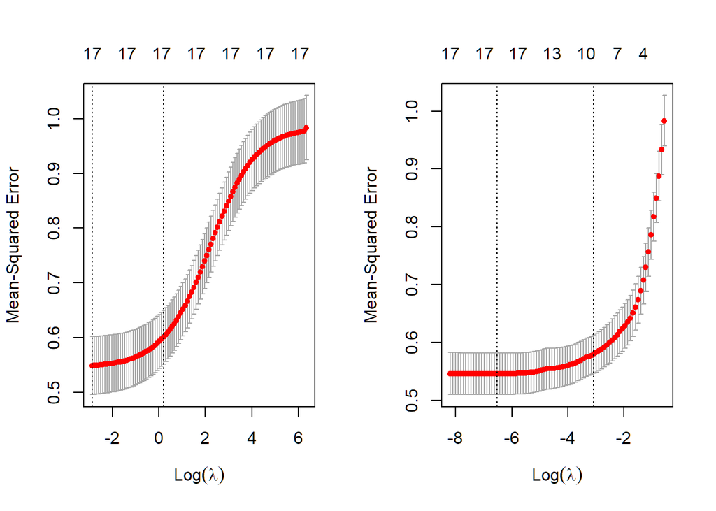

```r
par(mfrow=c(1, 2))
plot(cv_ridge)
plot(cv_lasso)
```

5. Display a matrix with the coefficients of linear model with all features as predictors, and of the objects `cv_ridge` and `cv_lasso` in the columns. Round all coefficients to three decimals. Compare the effects of the shrinkage.

```r
round(cbind(coef(lm(Grad.Rate ~ . , College[train, ])), coef(cv_ridge), coef(cv_lasso)), 3)
```

```
## 18 x 3 sparse Matrix of class "dgCMatrix"
##                         1      1
## (Intercept)  0.016  0.011  0.011
## Private      0.203  0.081  0.086
## Apps         0.720  0.048  0.120
## Accept      -0.690  0.029  .
## Enroll       0.130  0.023  .
## Top10perc    0.119  0.083  0.094
## Top25perc   -0.091 -0.081 -0.090
## F.Undergrad  0.150  0.012  .
## P.Undergrad -0.026 -0.034  .
## Outstate     0.317  0.113  0.231
## Room.Board   0.107  0.070  0.033
## Books       -0.075 -0.029 -0.019
## Personal    -0.103 -0.074 -0.085
## PhD         -0.119 -0.032  .
## Terminal     0.147  0.003  .
## S.F.Ratio   -0.046 -0.019  .
## perc.alumni  0.193  0.105  0.155
## Expend      -0.273  0.024  .
```

6. Obtain the predictions for the test set - check the help page for `predict.cv.glmnet()` - and compute and the test MSE’s for the ridge and lasso.

```r
pred_ridge <- predict(cv_ridge, newx = as.matrix(College[-train, -18]))

pred_lasso <- predict(cv_lasso, newx = as.matrix(College[-train, -18]))


ridge_mse  <- mean((College[-train, "Grad.Rate"] - pred_ridge)^2)

lasso_mse  <- mean((College[-train, "Grad.Rate"] - pred_lasso)^2)
```

7. Compare the test MSE for the filter method, the `step` function, and the ridge and lasso. Which method performs work best on the test data.

```r
data.frame(filter_mse, step_mse, ridge_mse, lasso_mse)
```

| filter_mse | step_mse | ridge_mse | lasso_mse |
| --- | --- | --- | --- |
| 0.574675 | 0.6035464 | 0.6087519 | 0.5792573 |

# 3 Interactions

So far we have not considered any pairwise interactions in our models. It may very well be that that the effect of one feature on `Grad.rate` is moderated by another feature. The problem with finding relevant interactions is that there are a lot of them (${17\choose2}=136$). The lasso, however, is particularly suited for such a task.

1. Obtain the model matrix of the model `Grad.Rate ~ .^2` for the training set (excluding the intercept), and cross-validate the lasso version of this model with `cv.glmnet()`. Save the the result as `cv_lasso2`

```r
cv_lasso2 <- cv.glmnet(x = model.matrix(Grad.Rate ~ .^2, College)[train, -1],
                       y = College$Grad.Rate[train],
                       alpha = 1,
                       type.measure = "mse")
```

2. Plot the object. How many variables have nonzero coefficients at the optimal value for `lambda`?

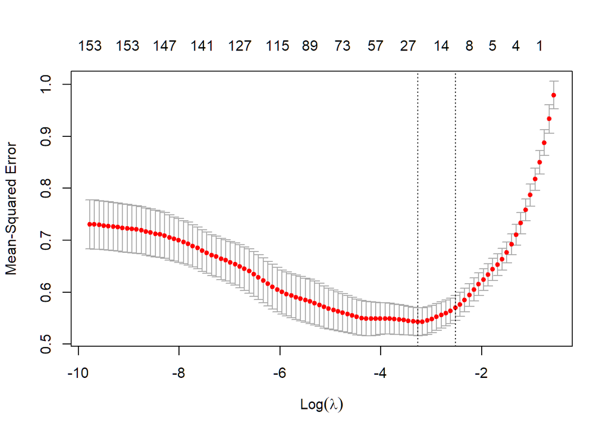

```r
plot(cv_lasso2)
```

3. Display the coefficients. How many of these are interaction effects?

```r
round(coef(cv_lasso2) , 3)
```

```
## 154 x 1 sparse Matrix of class "dgCMatrix"
##                              1
## (Intercept)              0.085
## Private                  .
## Apps                     0.079
## Accept                   .
## Enroll                   .
## Top10perc                0.098
## Top25perc               -0.090
## F.Undergrad              .
## P.Undergrad              .
## Outstate                 0.258
## Room.Board               0.001
## Books                    .
## Personal                -0.049
## PhD                      .
## Terminal                 .
## S.F.Ratio                .
## perc.alumni              0.145
## Expend                   .
## Private:Apps             .
## Private:Accept           .
## Private:Enroll           .
## Private:Top10perc        .
## Private:Top25perc        .
## Private:F.Undergrad      .
## Private:P.Undergrad      0.050
## Private:Outstate         .
## Private:Room.Board       .
## Private:Books            .
## Private:Personal         .
## Private:PhD              .
## Private:Terminal         .
## Private:S.F.Ratio        .
## Private:perc.alumni      .
## Private:Expend           .
## Apps:Accept              .
## Apps:Enroll              .
## Apps:Top10perc           .
## Apps:Top25perc           .
```

[output cut: 101 more lines]

```
## Personal:PhD             .
## Personal:Terminal        .
## Personal:S.F.Ratio       .
## Personal:perc.alumni     0.011
## Personal:Expend          .
## PhD:Terminal             .
## PhD:S.F.Ratio            .
## PhD:perc.alumni          .
## PhD:Expend               .
## Terminal:S.F.Ratio       .
## Terminal:perc.alumni     .
## Terminal:Expend          .
## S.F.Ratio:perc.alumni    .
## S.F.Ratio:Expend         .
## perc.alumni:Expend       .
```

4. Compute the test MSE for `cv_lasso2`. How does it compare to the models without interactions?

```r
pred_lasso2 <- predict(cv_lasso2, newx = model.matrix(Grad.Rate ~ .^2, College)[-train, -1])
(lasso2_mse   <- mean((College[-train, "Grad.Rate"] - pred_lasso2)^2))
```

```
## [1] 0.5712912
```

END OF LAB